# Class 10 - In class exercises

Hari Subhash

Date created: 2019-04-18

## Task 1: Examine the weather data

1. Use the `skim()` function from the `skimr` package to visually display all the variables in weather

```r
skim(weather)
```

```
Skim summary statistics
 n obs: 26115
 n variables: 15

-- Variable type:character -----------------------------------------------------
 variable missing complete     n min max empty n_unique
   origin       0    26115 26115   3   3     0        3

-- Variable type:integer -------------------------------------------------------
 variable missing complete     n  mean   sd p0 p25 p50 p75 p100     hist
      day       0    26115 26115 15.68 8.76  1   8  16  23   31 ▇▇▇▇▆▇▇▆
     hour       0    26115 26115 11.49 6.91  0   6  11  17   23 ▇▇▇▇▇▇▇▇

-- Variable type:numeric -------------------------------------------------------
   variable missing complete     n      mean     sd      p0     p25     p50     p75
       dewp       1    26114 26115   41.44    19.39   -9.94   26.06   42.08   57.92
      humid       1    26114 26115   62.53    19.4    12.74   47.05   61.79   78.79
      month       0    26115 26115    6.5      3.44    1       4       7       9
     precip       0    26115 26115    0.0045   0.03    0       0       0       0
   pressure    2729    23386 26115 1017.9      7.42  983.8  1012.9  1017.6  1023
       temp       1    26114 26115   55.26    17.79   10.94   39.92   55.4    69.98
      visib       0    26115 26115    9.26     2.06    0      10      10      10
   wind_dir     460    25655 26115  199.76   107.31    0     120     220     290
  wind_gust   20778     5337 26115   25.49     5.95   16.11   20.71   24.17   28.77
 wind_speed       4    26111 26115   10.52     8.54    0       6.9    10.36   13.81
       year       0    26115 26115 2013        0    2013    2013    2013    2013
    p100     hist
   78.08 ▁▃▆▇▆▇▇▅
  100    ▁▂▆▇▇▆▆▅
   12    ▇▅▇▃▅▇▅▇
    1.21 ▇▁▁▁▁▁▁▁
 1042.1  ▁▁▁▅▇▆▂▁
  100.04 ▁▅▇▇▇▇▃▁
   10    ▁▁▁▁▁▁▁▇
  360    ▆▃▂▆▆▇▇▆
   66.75 ▆▇▂▁▁▁▁▁
 1048.36 ▇▁▁▁▁▁▁▁
 2013    ▁▁▁▇▁▁▁▁

-- Variable type:POSIXct -------------------------------------------------------
  variable missing complete     n        min        max     median n_unique
 time_hour       0    26115 26115 2013-01-01 2013-12-30 2013-07-01     8714
```

2. Use `nrow()` to display the number of rows in the weather data

```r
nrow(weather)
```

```
[1] 26115
```

3. Use `dim()` to display the rows and columns of the weather data

```r
dim(weather)
```

```
[1] 26115    15
```

4. Use `names()` to display the column names of the weather data

```r
names(weather)
```

```
 [1] "origin"     "year"       "month"      "day"        "hour"       "temp"
 [7] "dewp"       "humid"      "wind_dir"   "wind_speed" "wind_gust"  "precip"
[13] "pressure"   "visib"      "time_hour"
```

5. Display the `head()` of the weather data

| origin | year | month | day | hour | temp | dewp | humid | wind_dir | wind_speed | wind_gust | precip | pressure | visib | time_hour |
| --- | --- | --- | --- | --- | --- | --- | --- | --- | --- | --- | --- | --- | --- | --- |
| EWR | 2013 | 1 | 1 | 1 | 39.02 | 26.06 | 59.37 | 270 | 10.35702 | NA | 0 | 1012.0 | 10 | 2013-01-01 01:00:00 |
| EWR | 2013 | 1 | 1 | 2 | 39.02 | 26.96 | 61.63 | 250 | 8.05546 | NA | 0 | 1012.3 | 10 | 2013-01-01 02:00:00 |
| EWR | 2013 | 1 | 1 | 3 | 39.02 | 28.04 | 64.43 | 240 | 11.50780 | NA | 0 | 1012.5 | 10 | 2013-01-01 03:00:00 |
| EWR | 2013 | 1 | 1 | 4 | 39.92 | 28.04 | 62.21 | 250 | 12.65858 | NA | 0 | 1012.2 | 10 | 2013-01-01 04:00:00 |
| EWR | 2013 | 1 | 1 | 5 | 39.02 | 28.04 | 64.43 | 260 | 12.65858 | NA | 0 | 1011.9 | 10 | 2013-01-01 05:00:00 |
| EWR | 2013 | 1 | 1 | 6 | 37.94 | 28.04 | 67.21 | 240 | 11.50780 | NA | 0 | 1012.4 | 10 | 2013-01-01 06:00:00 |

6. Display the `tail()` of the weather data

```r
tail(weather)
```

[output not shown]

7. Display a random 10 rows from the weather data using `sample_n()`

```r
sample_n()
```

[output not shown]

8. What are the primary keys of the weather data? i.e. which column(s) can be used to uniquely identify each observation in the weather data? Hint: `group_by()` with `filter(n() > 1)` to check if there are more than one observation per group.

| origin | year | month | day | hour | temp | dewp | humid | wind_dir | wind_speed | wind_gust | precip | pressure | visib | time_hour |
| --- | --- | --- | --- | --- | --- | --- | --- | --- | --- | --- | --- | --- | --- | --- |
| EWR | 2013 | 11 | 3 | 1 | 51.98 | 39.02 | 61.15 | 310 | 6.90468 | NA | 0 | 1009.8 | 10 | 2013-11-03 01:00:00 |
| EWR | 2013 | 11 | 3 | 1 | 50.00 | 39.02 | 65.80 | 290 | 5.75390 | NA | 0 | 1010.5 | 10 | 2013-11-03 01:00:00 |
| JFK | 2013 | 11 | 3 | 1 | 53.96 | 37.94 | 54.51 | 320 | 9.20624 | NA | 0 | 1009.8 | 10 | 2013-11-03 01:00:00 |
| JFK | 2013 | 11 | 3 | 1 | 51.98 | 37.94 | 58.62 | 310 | 6.90468 | NA | 0 | 1010.5 | 10 | 2013-11-03 01:00:00 |
| LGA | 2013 | 11 | 3 | 1 | 55.04 | 39.02 | 54.67 | 330 | 9.20624 | NA | 0 | 1009.3 | 10 | 2013-11-03 01:00:00 |
| LGA | 2013 | 11 | 3 | 1 | 53.96 | 39.92 | 58.89 | 310 | 8.05546 | NA | 0 | 1010.2 | 10 | 2013-11-03 01:00:00 |

## Task 2: Explore the indepedent variable

Use a combination of text, tables and charts to explore the nature of the independent variable

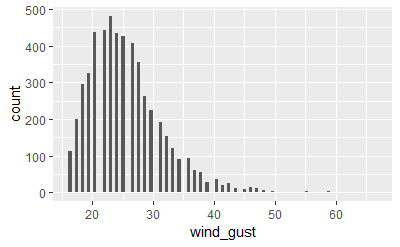

## Task 3. Explore a relationship

Explore the relationship between departure delay and a variable of your choice.

# looking at seeing a relationship between the month and the effect of temperature

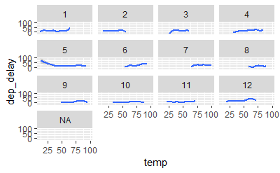

[output not shown]

[output cut: 990 more lines]